# On importe le dataset nettoyé

```python
import pandas as pd
import numpy as np
import seaborn as sns

df = pd.read_csv('data_clean.csv')
df.head()
```

|  | Unnamed: 0 | gender | age | age_o | d_age | race | race_o | samerace | importance_same_race | importance_same_religion | ... | expected_num_matches | like | guess_prob_liked | met | decision | decision_o | match | note_partner | note_from_partner | note_diff |
| --- | --- | --- | --- | --- | --- | --- | --- | --- | --- | --- | --- | --- | --- | --- | --- | --- | --- | --- | --- | --- | --- |
| 0 | 0 | 0.0 | 21.0 | 27.0 | 6.0 | 0.0 | 3.0 | 0.0 | 2.0 | 4.0 | ... | 4.0 | 7.0 | 6.0 | 0.0 | 1.0 | 0.0 | 0.0 | 7.1 | 7.3 | 0.503366 |
| 1 | 1 | 0.0 | 21.0 | 22.0 | 1.0 | 0.0 | 3.0 | 0.0 | 2.0 | 4.0 | ... | 4.0 | 7.0 | 5.0 | 1.0 | 1.0 | 0.0 | 0.0 | 7.1 | 7.0 | 0.482132 |
| 2 | 2 | 0.0 | 21.0 | 22.0 | 1.0 | 0.0 | 0.0 | 1.0 | 2.0 | 4.0 | ... | 4.0 | 7.0 | 5.2 | 1.0 | 1.0 | 1.0 | 1.0 | 7.2 | 10.0 | 0.741635 |
| 3 | 3 | 0.0 | 21.0 | 23.0 | 2.0 | 0.0 | 3.0 | 0.0 | 2.0 | 4.0 | ... | 4.0 | 7.0 | 6.0 | 0.0 | 1.0 | 1.0 | 1.0 | 6.8 | 7.9 | 0.527866 |
| 4 | 4 | 0.0 | 21.0 | 24.0 | 3.0 | 0.0 | 2.0 | 0.0 | 2.0 | 4.0 | ... | 4.0 | 6.0 | 6.0 | 0.0 | 1.0 | 1.0 | 1.0 | 6.2 | 8.0 | 0.497129 |

5 rows × 51 columns

On empêche les messages d'avertissements de s'afficher

```python
# SERT A NE PAS AFFICHER LES MESSAGES D'AVERTISSEMENTS :
import sys
if not sys.warnoptions:
    import warnings
    warnings.simplefilter("ignore")
```

# Suppression de variables :

On supprime les trois variables suivantes. La première étant inutile, et les deux autres parce qu'elles nous en disent bien trop sur la prédiction de 'match'.

```python
df = df.drop(['Unnamed: 0','decision','decision_o'],axis=1)
```

# Construction de X et y :

On construit X (l'ensemble de nos variables descriptives) et y (notre target) pour le dataset original (df) :

```python
X = df.drop('match',axis=1)
y = df['match']
```

# Utilisation de la fonction train_test_split :

```python
import sklearn
from sklearn.model_selection import train_test_split
X_train, X_test, y_train, y_test = train_test_split(X, y, test_size=0.2, shuffle=True, random_state=100, stratify=df['match'])
```

# Création de nouveaux ensembles d'apprentissage et de test, en doublant les match=1 sur le train_set :

Cela aura pour intérêt de ré-équilibrer le dataset qui contient beaucoup plus de matchs ratés que de matchs réussis. On pourra alors se servir de ces deux dataset pour comparer nos modèles.

On créer un ensemble d'apprentissage et un ensemble de test.

```python
df_train, df_test = train_test_split(df,test_size = 0.2, shuffle = True, random_state=100, stratify=df['match'])
```

On créer 'df_train_dp', qui contient une copie de tous les individus de 'df_train' ayant 'match'=1. Puis on concatene 'df_train' et 'df_train_dp'. Puis simplifier, on double les match réussis dans l'ensemble d'apprentissage.

```python
df_train_dp=df_train[df_train['match']==1]
df_double_train=pd.concat([df_train,df_train_dp])
```

On créer ensuite 'X_double_train' et 'y_double_train' :

```python
X_double_train = df_double_train.copy()
y_double_train = X_double_train.pop('match')
```

On créer ensuite 'X_test' et 'y_test'

```python
X_test = df_test.copy()
y_test = X_test.pop('match')
```

Enfin, on créer 'X_double_test' et 'y_double_test'

```python
X_double_test = X_test.copy()
y_double_test = y_test.copy()
```

On ré-index df_double_train et on affiche la répartition de matchs réussis/ratés dans l'ensemble d'apprentissage :

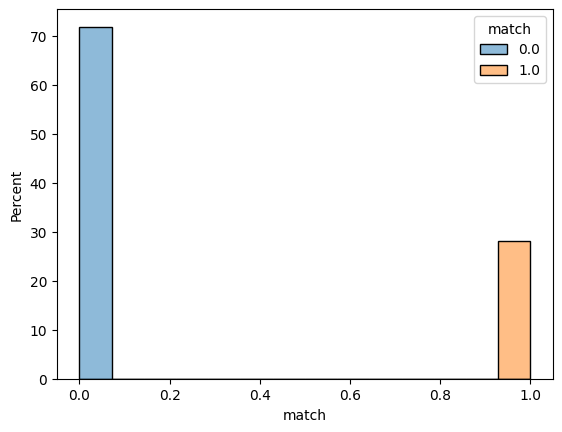

```python
df_double_train = df_double_train.reset_index(drop = True)
sns.histplot(data = df_double_train, x = 'match', hue = 'match', stat = 'percent')
```

# On construit un arbre de décision :

On construit deux arbres :

- Un pour le dataset original.
- Un pour le dataset ou les match=1 sont doublés sur le train_set.

```python
from sklearn.tree import DecisionTreeClassifier
model_tree = DecisionTreeClassifier(max_depth=6,random_state=100)
model_tree.fit(X_train, y_train)

print('Score sur le test-set :',model_tree.score(X_test, y_test))

print("=========================================================")

model_double_tree = DecisionTreeClassifier(max_depth=6,random_state=100)
model_double_tree.fit(X_double_train, y_double_train)

print('Score sur le test-set doublé :',model_double_tree.score(X_double_test, y_double_test))
```

```
Score sur le test-set : 0.8526379624014554
=========================================================
Score sur le test-set doublé : 0.8229229836264402
```

```python
y_pred_tree = model_tree.predict(X_test)

from sklearn.metrics import confusion_matrix
print("Matrice de confusion du modèle :\n",confusion_matrix(y_test,y_pred_tree))

from sklearn.metrics import classification_report
print(classification_report(y_pred_tree,y_test, zero_division=0))

print('================Doublée=================')
y_double_pred_tree = model_double_tree.predict(X_double_test)

print("Matrice de confusion du modèle :\n",confusion_matrix(y_double_test,y_double_pred_tree))


from sklearn.metrics import classification_report
print(classification_report(y_double_pred_tree,y_double_test, zero_division=0))
```

```
Matrice de confusion du modèle :
 [[1300   79]
 [ 164  106]]
              precision    recall  f1-score   support

         0.0       0.94      0.89      0.91      1464
         1.0       0.39      0.57      0.47       185

    accuracy                           0.85      1649
   macro avg       0.67      0.73      0.69      1649
weighted avg       0.88      0.85      0.86      1649

================Doublée=================
Matrice de confusion du modèle :
 [[1221  158]
 [ 134  136]]
              precision    recall  f1-score   support

         0.0       0.89      0.90      0.89      1355
         1.0       0.50      0.46      0.48       294

    accuracy                           0.82      1649
   macro avg       0.69      0.68      0.69      1649
weighted avg       0.82      0.82      0.82      1649
```

On constate que les métrique pour l'arbre de décision ont tendance a être moins bonnes lorsque l'on double les matchs réussis. Il a du mal à apprendre avec notre modèle complexe.

# On construit une forêt aléatoire :

On construit deux modèles différents, un pour le dataset original, et un pour le dataset ou les match=1 sont doublés sur le train_set :

```python
from sklearn.ensemble import RandomForestClassifier
model_random_forest = RandomForestClassifier(max_depth=6,n_estimators=100,random_state=100)
model_random_forest.fit(X_train, y_train)

model_random_forest_double = RandomForestClassifier(max_depth=6,n_estimators=100,random_state=100)
model_random_forest_double.fit(X_double_train, y_double_train)
```

```
RandomForestClassifier(max_depth=6, random_state=100)
```

On affiche plusieurs métriques pour évaluer les deux modèles :

```python
y_pred_random_forest = model_random_forest.predict(X_test)

from sklearn.metrics import confusion_matrix
print("Matrice de confusion du modèle :\n",confusion_matrix(y_test,y_pred_random_forest))

from sklearn.metrics import classification_report
print(classification_report(y_test,y_pred_random_forest, zero_division=0))


print('================Doublée=================')

y_double_pred_random_forest = model_random_forest_double.predict(X_double_test)

print("Matrice de confusion du modèle :\n",confusion_matrix(y_double_test,y_double_pred_random_forest))

from sklearn.metrics import classification_report
print(classification_report(y_double_test,y_double_pred_random_forest, zero_division=0))
```

```
Matrice de confusion du modèle :
 [[1369   10]
 [ 216   54]]
              precision    recall  f1-score   support

         0.0       0.86      0.99      0.92      1379
         1.0       0.84      0.20      0.32       270

    accuracy                           0.86      1649
   macro avg       0.85      0.60      0.62      1649
weighted avg       0.86      0.86      0.83      1649

================Doublée=================
Matrice de confusion du modèle :
 [[1296   83]
 [ 149  121]]
              precision    recall  f1-score   support

         0.0       0.90      0.94      0.92      1379
         1.0       0.59      0.45      0.51       270

    accuracy                           0.86      1649
   macro avg       0.75      0.69      0.71      1649
weighted avg       0.85      0.86      0.85      1649
```

Nous remarquons que le dataset doublé améliore le rappel de la classe 1. Et c'est exactement ce qu'on cherchait à faire. Comme la classe 1 est largement minoritaire, on essaye de corriger au mieux les erreurs de classification sur la classe 1.

# On construit un modèle de régression logistique :

On regarde les variables qui sont trop correlées entre elles pour les enlever. En effet, le modèle de regression logistique supporte mal les variables corrélées. On calcul ici le coefficient de Pearson pour chacune des corrélation. Si ce dernier est supérieur à 0.5, on estime que les deux variables sont trop corrélées.

```python
"""seuil = 0.5
for i in range(len(df.columns)) :
    for j in range(i):
        if abs(df.corr()[df.columns[i]][j]) > seuil :
            print('attention', df.columns[i],'est trop correlée avec',df.corr()[df.columns[i]].index[j])"""

# Voici le résultat de cette exécution :
"""attention intelligence_o est trop correlée avec sincere_o
attention funny_o est trop correlée avec attractive_o
attention ambition_o est trop correlée avec intelligence_o
attention shared_interests_o est trop correlée avec funny_o
attention intelligence_partner est trop correlée avec sincere_partner
attention funny_partner est trop correlée avec attractive_partner
attention ambition_partner est trop correlée avec intelligence_partner
attention shared_interests_partner est trop correlée avec funny_partner
attention like est trop correlée avec attractive_partner
attention like est trop correlée avec sincere_partner
attention like est trop correlée avec intelligence_partner
attention like est trop correlée avec funny_partner
attention like est trop correlée avec shared_interests_partner
attention note_partner est trop correlée avec attractive_partner
attention note_partner est trop correlée avec sincere_partner
attention note_partner est trop correlée avec intelligence_partner
attention note_partner est trop correlée avec funny_partner
attention note_partner est trop correlée avec ambition_partner
attention note_partner est trop correlée avec shared_interests_partner
attention note_partner est trop correlée avec like
attention note_from_partner est trop correlée avec attractive_o
attention note_from_partner est trop correlée avec sincere_o
attention note_from_partner est trop correlée avec intelligence_o
attention note_from_partner est trop correlée avec funny_o
attention note_from_partner est trop correlée avec ambition_o
attention note_from_partner est trop correlée avec shared_interests_o
attention note_diff est trop correlée avec attractive_o
attention note_diff est trop correlée avec sincere_o
attention note_diff est trop correlée avec intelligence_o
attention note_diff est trop correlée avec funny_o
attention note_diff est trop correlée avec attractive_partner
attention note_diff est trop correlée avec sincere_partner
attention note_diff est trop correlée avec intelligence_partner
attention note_diff est trop correlée avec funny_partner
attention note_diff est trop correlée avec like
attention note_diff est trop correlée avec note_partner
attention note_diff est trop correlée avec note_from_partner"""
```

```
'attention intelligence_o est trop correlée avec sincere_o\nattention funny_o est trop correlée avec attractive_o\nattention ambition_o est trop correlée avec intelligence_o\nattention shared_interests_o est trop correlée avec funny_o\nattention intelligence_partner est trop correlée avec sincere_pa…
```

On drop toutes les variables qui sont trop corrélées à d'autres :

```python
df_logic = df.drop(['sincere_o','attractive_o','intelligence_o','ambition_o', 'funny_o', 'sincere_partner', 'attractive_partner',
                   'intelligence_partner','funny_partner','shared_interests_partner','attractive', 'sincere', 'intelligence',
                   'funny', 'ambition','note_diff','ambition_partner', 'shared_interests_o','like'], axis = 1)
```

On fait tourner une seconde fois ce code pour voir s'il reste des variables trop fortement corrélées...

```python
seuil = 0.5
for i in range(len(df_logic.columns)) :
    for j in range(i):
        if abs(df_logic.corr()[df_logic.columns[i]][j]) > seuil :
            print('attention', df_logic.columns[i],'est trop correlée avec',df_logic.corr()[df_logic.columns[i]].index[j])
```

On constate que rien ne s'affiche, c'est qu'il ne reste plus aucune variable corrélée à une autre.

On créer X_logic et y_logic (pour la régression logistique) puis on utilise la fonction train_test_split :

```python
X_logic = df_logic.copy()
y_logic = X_logic.pop('match')

X_logic_train , X_logic_test, y_logic_train, y_logic_test = train_test_split(X_logic,y_logic,test_size = 0.2, shuffle = True, random_state = 100, stratify = df_logic['match'])
```

On construit le modèle et on l'entraine :

```python
from sklearn.linear_model import LogisticRegression
model_reg = LogisticRegression(random_state=100)
model_reg.fit(X_logic_train, y_logic_train)
```

```
LogisticRegression(random_state=100)
```

On affiche plusieurs métriques pour l'évaluer :

```python
y_pred_reg = model_reg.predict(X_logic_test)

from sklearn.metrics import confusion_matrix
print("Matrice de confusion du modèle :\n",confusion_matrix(y_logic_test,y_pred_reg))

from sklearn.metrics import classification_report
print(classification_report(y_pred_reg,y_logic_test, zero_division=0))
```

```
Matrice de confusion du modèle :
 [[1340   39]
 [ 215   55]]
              precision    recall  f1-score   support

         0.0       0.97      0.86      0.91      1555
         1.0       0.20      0.59      0.30        94

    accuracy                           0.85      1649
   macro avg       0.59      0.72      0.61      1649
weighted avg       0.93      0.85      0.88      1649
```